# Properties of MLE: Uncertainty in Parameters

INFO 521 · Module 3 · Lecture B — Properties of the MLE

Greg Chism

College of Information Science · University of Arizona

August 2026

## Learning outcomes

By the end of this module you should be able to:

1. **Show the MLE solution is unique** — that the log-likelihood has a single maximum (a negative-definite Hessian).
2. **State what unbiasedness of $\hat{\mathbf{w}}$ does and does not mean** — and the common claims it is *not*.
3. **Quantify parameter uncertainty** — via $\mathrm{Cov}[\hat{\mathbf{w}}]$ and the Fisher information.

## Recap: likelihood and the MLE

The linear-Gaussian likelihood:

$$p(\mathbf{y}\mid\mathbf{X},\mathbf{w},\sigma^2)
\;=\; \prod_{n=1}^{N} \mathcal{N}\!\left(y_n \,\middle|\, \mathbf{w}^{\!\top}\mathbf{x}_n,\ \sigma^2\right)$$

Its maximizers — the MLE (derived in the likelihood lecture of this module):

$$\hat{\mathbf{w}} = \left(\mathbf{X}^{\!\top}\mathbf{X}\right)^{-1}\mathbf{X}^{\!\top}\mathbf{y},
\qquad
\hat{\sigma}^2 = \tfrac{1}{N}\left(\mathbf{y}^{\!\top}\mathbf{y} - \mathbf{y}^{\!\top}\mathbf{X}\hat{\mathbf{w}}\right)$$

# Unique, unbiased, and how uncertain.

## Property 1 · Uniqueness

The log-likelihood — we write it $\ell(\mathbf{w}) = \log p(\mathbf{y}\mid\mathbf{X},\mathbf{w},\sigma^2)$, reserving $\mathcal{L}$ for losses:

$$\ell(\mathbf{w}) = -\tfrac{N}{2}\log 2\pi \;-\; N\log\sigma
\;-\; \tfrac{1}{2\sigma^2}\sum_{n=1}^{N}\left(y_n - \mathbf{w}^{\!\top}\mathbf{x}_n\right)^2$$

Gradient — vanishes at the normal equations:

$$\frac{\partial \ell}{\partial \mathbf{w}}
= \tfrac{1}{\sigma^2}\left(\mathbf{X}^{\!\top}\mathbf{y} - \mathbf{X}^{\!\top}\mathbf{X}\mathbf{w}\right)$$

Hessian — constant and **negative definite** ($\mathbf{v}^{\!\top}\mathbf{H}\mathbf{v} < 0\ \ \forall\,\mathbf{v}\neq\mathbf{0}$):

$$\mathbf{H} \;=\; \frac{\partial^2 \ell}{\partial \mathbf{w}\,\partial \mathbf{w}^{\!\top}}
\;=\; -\tfrac{1}{\sigma^2}\,\mathbf{X}^{\!\top}\mathbf{X}
\quad\Longrightarrow\quad \text{a single, unique maximum.}$$

The same $\mathbf{X}^{\!\top}\mathbf{X}$ full-column-rank condition from Module 1 — now reappearing as a negative-definite Hessian.

## The generative picture

[figure not shown]

## Expectation — a reminder

For a random vector $\mathbf{x}$ with density $p(\mathbf{x})$:

$$\mathbb{E}_{p(\mathbf{x})}[f(\mathbf{x})] = \int f(\mathbf{x})\,p(\mathbf{x})\,d\mathbf{x}$$

**Mean** $\;\boldsymbol{\mu} = \mathbb{E}[\mathbf{x}]\qquad$ **Covariance** $\;\mathrm{Cov}[\mathbf{x}] = \mathbb{E}\!\left[(\mathbf{x}-\boldsymbol{\mu})(\mathbf{x}-\boldsymbol{\mu})^{\!\top}\right]$

## Property 2 · Unbiasedness

Take the expectation of $\hat{\mathbf{w}}$ over datasets from the generating process (only $\mathbf{y}$ is random; $\mathbf{X}$ is fixed):

$$\mathbb{E}[\hat{\mathbf{w}}] = \left(\mathbf{X}^{\!\top}\mathbf{X}\right)^{-1}\mathbf{X}^{\!\top}\,\mathbb{E}[\mathbf{y}]$$

$$= \left(\mathbf{X}^{\!\top}\mathbf{X}\right)^{-1}\mathbf{X}^{\!\top}\mathbf{X}\mathbf{w}$$

$$= \mathbf{w} \qquad\Longrightarrow\qquad \hat{\mathbf{w}}\ \text{is unbiased.}$$

## What “unbiased” means — and doesn’t

**Unbiased means:** across repeated size-$N$ samples from the generating process, the collection of estimates $\hat{\mathbf{w}}$ is **centered** on the true $\mathbf{w}$.

It is **not** the same as:

- **“more data ⇒ better estimates”** — true here, but that is a *separate* sample-size effect, not what unbiasedness asserts;
- **UMVU** (uniformly minimum-variance unbiased) — a strictly stronger claim about being *closest*, which unbiasedness alone does not give;
- a guarantee of being best for *your* dataset — a **biased** estimator can land closer to $\mathbf{w}$ from *less* data.

## Property 3 · Covariance

The punchline first — the parameter covariance is

$$\boxed{\;\mathrm{Cov}[\hat{\mathbf{w}}] \;=\; \sigma^2\left(\mathbf{X}^{\!\top}\mathbf{X}\right)^{-1}\;}$$

Derived in full in the appendix → appendix-covariance.html.

## Fisher information

The (expected) Fisher information is the curvature of the log-likelihood:

$$\mathcal{I} \;=\; \mathbb{E}\!\left[-\,\frac{\partial^2 \log p(\mathbf{y}\mid\mathbf{X},\mathbf{w},\sigma^2)}{\partial \mathbf{w}\,\partial \mathbf{w}^{\!\top}}\right]
\;=\; \tfrac{1}{\sigma^2}\,\mathbf{X}^{\!\top}\mathbf{X}
\qquad\Longrightarrow\qquad
\mathrm{Cov}[\hat{\mathbf{w}}] \;=\; \mathcal{I}^{-1}$$

- **Diagonal** $\mathcal{I}_{jj}$ — information about each parameter on its own;
- **Off-diagonal** $\mathcal{I}_{jk}$ — information *shared* between a pair (their estimates trade off).

## Parameter uncertainty on NHANES

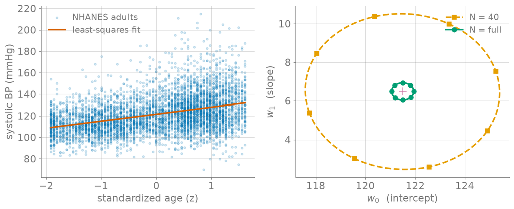

Figure 1: Cov[ŵ] = σ̂²(XᵀX)⁻¹ shrinks as N grows: N = 40 (orange, dashed) vs. full N (green, solid).

## Through-line

Uniqueness (negative-definite Hessian) → Fisher information $\mathcal{I} = \tfrac{1}{\sigma^2}\mathbf{X}^{\!\top}\mathbf{X}$ → (Module 5) the Laplace approximation’s posterior covariance $\mathbf{H}^{-1} = \mathcal{I}^{-1}$.

The curvature of the log-likelihood is one object doing three jobs, three modules apart — **same $\mathbf{X}^{\!\top}\mathbf{X}$, same inverse.**

## Recap + checkpoint preview

Three properties of the linear-Gaussian MLE:

1. **Unique** — $\mathbf{H} = -\tfrac{1}{\sigma^2}\mathbf{X}^{\!\top}\mathbf{X}$ is negative definite.
2. **Unbiased** — $\mathbb{E}[\hat{\mathbf{w}}] = \mathbf{w}$.
3. **Uncertain, quantifiably** — $\mathrm{Cov}[\hat{\mathbf{w}}] = \sigma^2(\mathbf{X}^{\!\top}\mathbf{X})^{-1} = \mathcal{I}^{-1}$.

**Checkpoint quiz 1.2** (Week 3, D2L) gates milestone 1.2 on reproducing the **uniqueness** and **unbiasedness** arguments; the MLE == OLS check lives in Homework Unit 3.